# Graphics manual

Lasse Rukolainen

1/5/2018

## Regression plot

Let’s first make a plot to illustrate a linear regression analysis, using the **tips** data in the **reshape2** package. The resulting plot will display how the presence of smokers in a party influences the association between the size of the total bill and the amount of tip received.

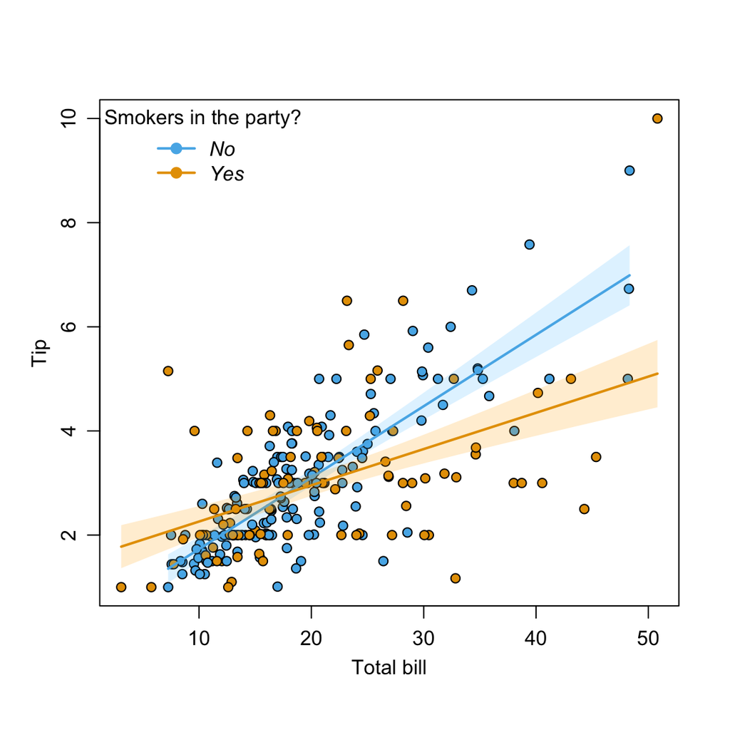

```r
data(tips,package='reshape2')
par(mgp=c(2,0.8,0))
with(tips,reg.plot(x=total_bill,y=tip,group=smoker,xlab='Total bill',ylab='Tip',
                   leg.title='Smokers in the party?'))
```

## Color highlight

This section is to show how to easily highlight a given set of points in scatter plot. I’ll use a species data from the **vegan** package to plot an ordination of community composition and then highlight those samples that had a soil Nitrate concentration higher than 20. First, get the data, calculate the ordination and also make a clustering of the communities for illustration:

```r
require(vegan,quietly = T)
data(varespec)
data(varechem)
D = vegdist(varespec)
ord = cmdscale(D,eig=T)
groups = factor(cutree(hclust(D,'ward.D2'),2))
```

Next, define highlight of points and make the plot:

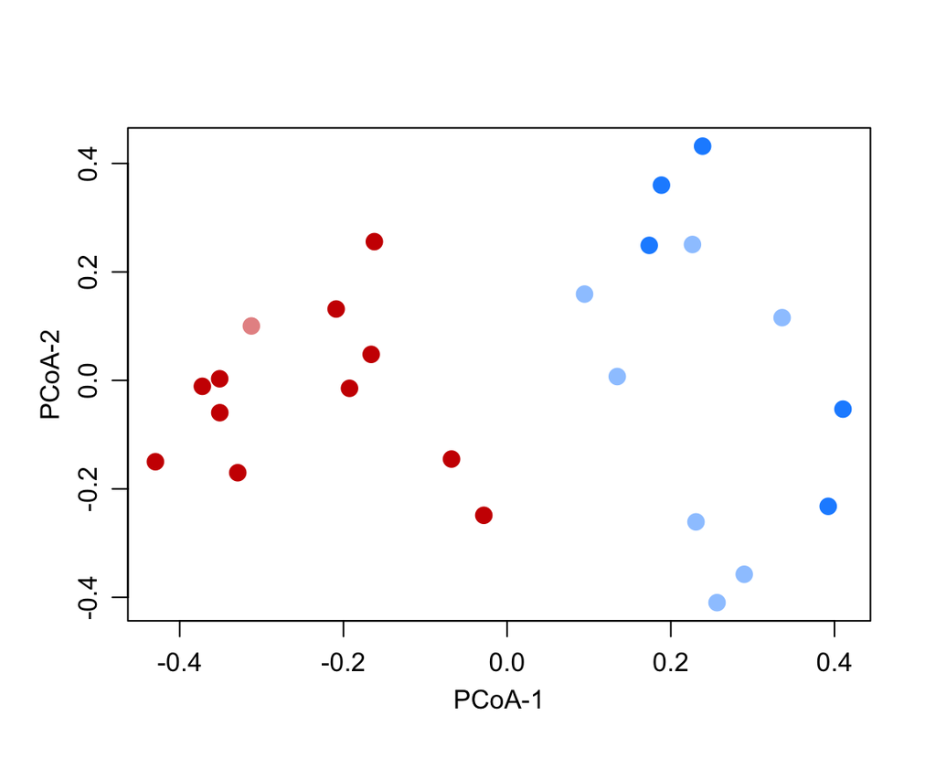

```r
cols = color.highlight(groups,selection = varechem$N>20)

par(mgp=c(2,0.8,0))
plot(ord$points,pch=16,col=cols,cex=1.5,xlab='PCoA-1',ylab='PCoA-2')
```

## Ordination plotting

Here I’ll demostrate how to plot pretty ordination graphs (or any scatter-type graphs). For simplicity, the previous example will be used here as well. The default evaluation of the **plot.pcoa** function, using an ordination object (or a matrix of x and y values), including a grouping factor, plots the points, concnetration ellipses around the grouo centroids, a spider connecting each point to the group centroid, and a group label at the centroid. If eigenvalues are included in the ordination object, the proportion of variance accounted by the axes is indicated in the axis labels.

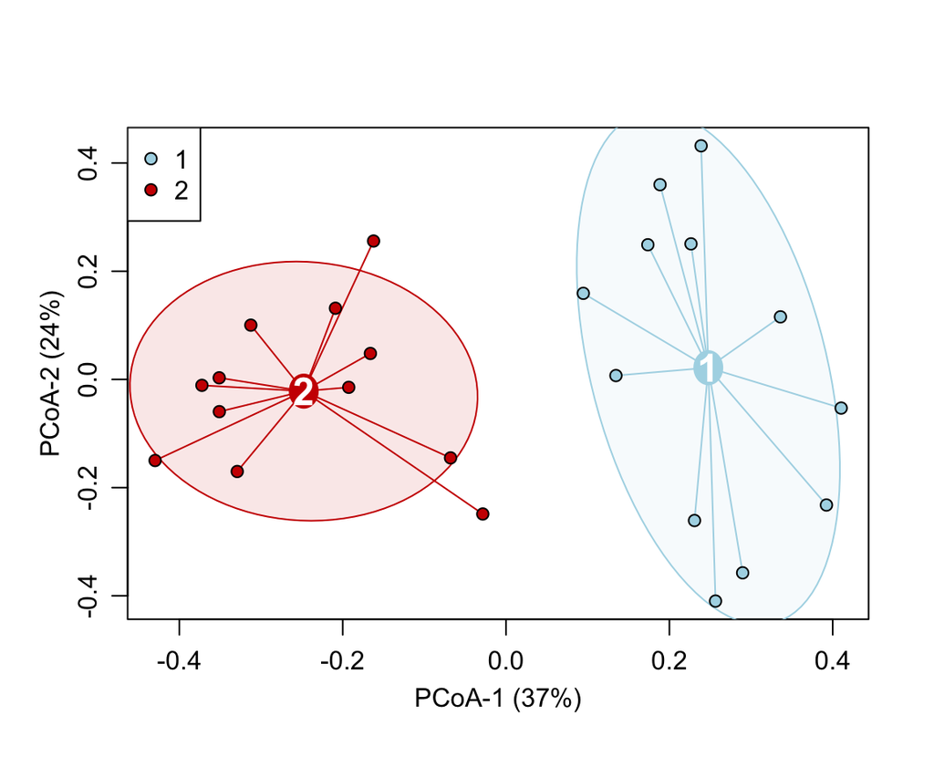

```r
par(mgp=c(2,0.8,0))
plot.pcoa(ord,groups)
```

There are many ways to modify the plot. One can, e.g., control the colors and line weights as in any plot, as well as choose whether ellipses, spiders, or points should be plotted. For example:

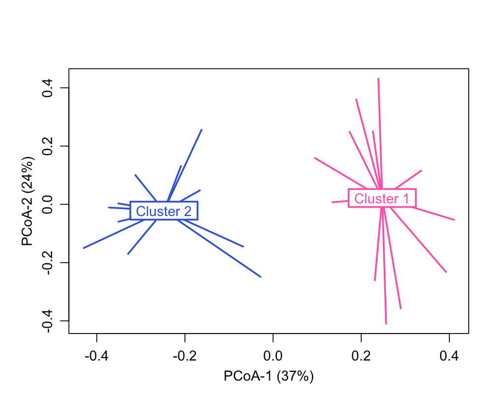

```r
cols = c('hotpink','royalblue')
levels(groups) = c('Cluster 1','Cluster 2')
par(mgp=c(2,0.8,0))
plot.pcoa(ord,groups,ellipse=F,cols=cols,lab.type = 'box',lab.cex=1,type='n',lwd.spider=2,legend = F)
```